# Linear Model LM - Predicting Bike Sharing Demand in the Cities

# Conducting Univariate Analysis

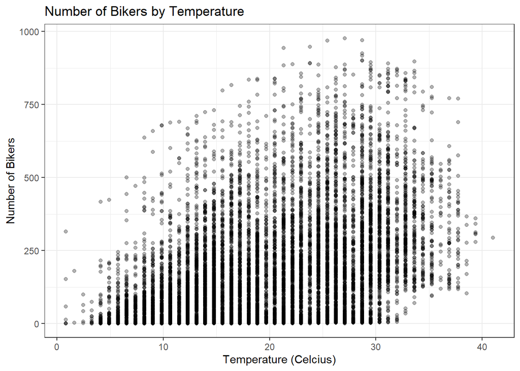

```r
ggplot(train_data, aes(temp, count)) + geom_point(alpha = 0.3) + theme_bw() +
  labs(title = "Number of Bikers by Temperature") +
  xlab("Temperature (Celcius)") +
  ylab("Number of Bikers")
```

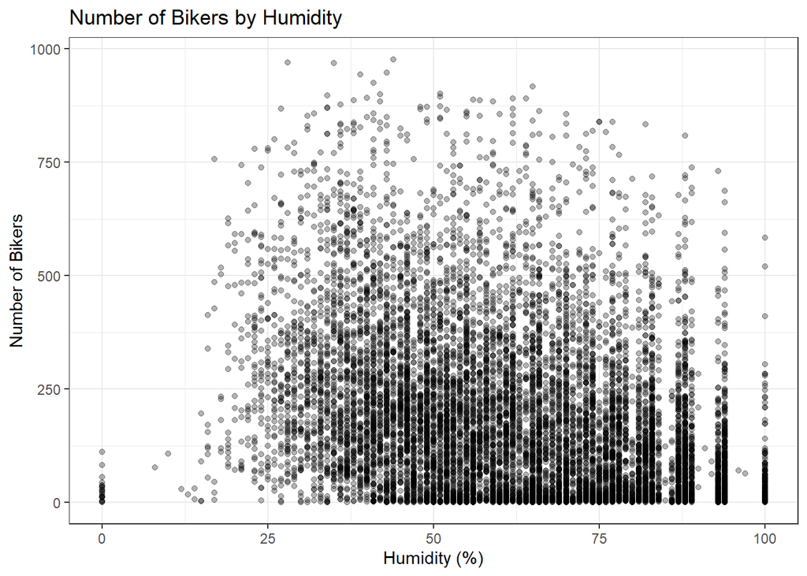

```r
ggplot(train_data, aes(humidity, count)) + geom_point(alpha = 0.3) + theme_bw() +
  labs(title = "Number of Bikers by Humidity") +
  xlab("Humidity (%)") +
  ylab("Number of Bikers")
```

Observations: - Every time a bike is shared, the temperature is noted - Most people won’t rent a bike when it is too hot or too cold. More bikes are rented when the temperature is pleasant. - A high number of bikes are rented when the temperature is around 16 degree celsius and 26 degree celsius.

##When do casual bikers increase the most?

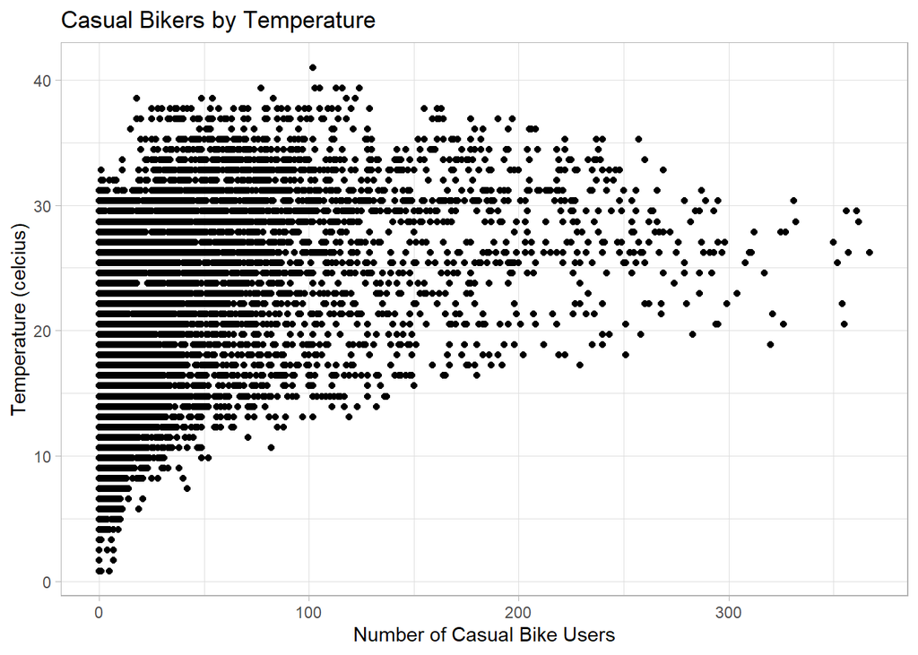

```r
ggplot(train_data, aes(casual, temp))+ geom_point() + theme_light() +
  labs(x = "Number of Casual Bike Users",
       y = "Temperature (celcius)",
       title = "Casual Bikers by Temperature")
```

##Showing Correlation Heatmap among the Numeric Virables

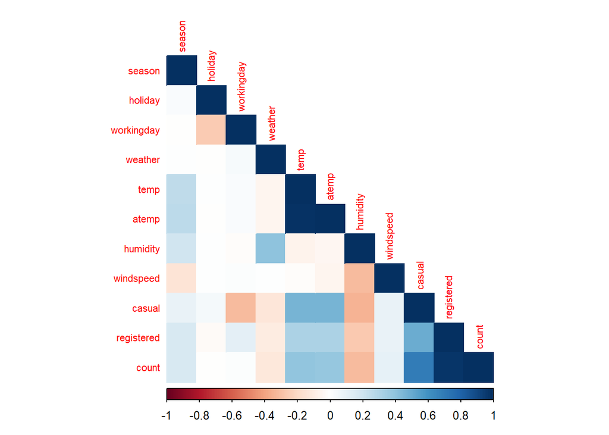

```r
library(dplyr)
numeric_train_data <- train_data %>% select_if(is.numeric)
cor_matrix <- cor(numeric_train_data)

# Create the correlation plot
corrplot(cor_matrix, method = "color", type = "lower", tl.cex = 0.7)
```

temp and atemp have high correlation. Registered and count have high correlation also.

### Plotting number of bikes rentend across four seasons

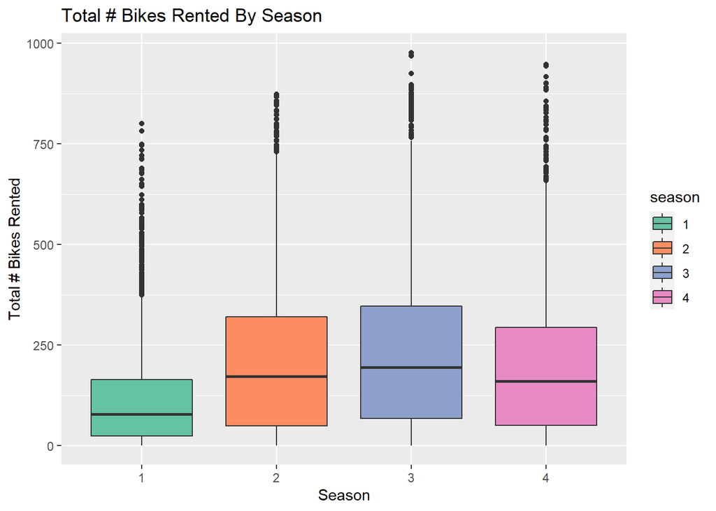

```r
library(ggplot2)

#Create a joint scatter plot for 'temp' vs 'atemp'
train_data$season <- as.factor(train_data$season)

# Create a box plot for 'cnt' by 'season'
ggplot(train_data, aes(x = season, y = count, fill = season, group = season)) +
  geom_boxplot() +
  labs(title = "Total # Bikes Rented By Season") +
  scale_fill_brewer(palette = "Set2") +
  xlab("Season") +
  ylab("Total # Bikes Rented")
```

Observation: - The cant column is an important column for analysis and the outliers are good for the business because we are working with Bike Sharing Data. So, we will not treat them.

###Feature Selection for modeling

##All Rentals by Date

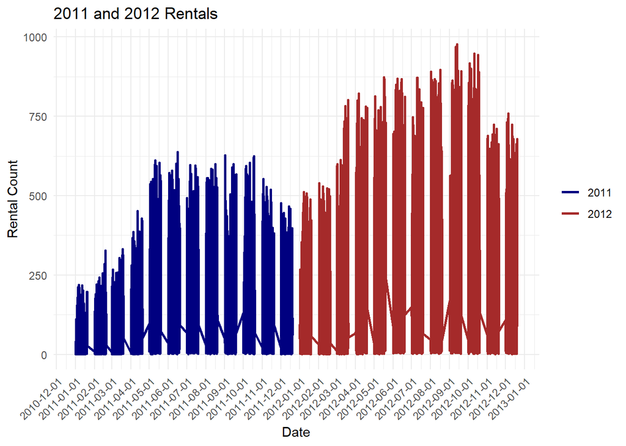

```r
df_2011 <- train_data %>% filter(year(datetime) == 2011)
df_2012 <- train_data %>% filter(year(datetime) == 2012)


ggplot() +
  geom_line(data = df_2011, aes(x = datetime, y = count, color = "2011"), size = 1) +
  geom_line(data = df_2012, aes(x = datetime, y = count, color = "2012"), size = 1) +
  scale_color_manual(values = c("2011" = "navy", "2012" = "brown")) +
  labs(x = "Date", y = "Rental Count", title = "2011 and 2012 Rentals") +
  theme_minimal() +
  theme(legend.title = element_blank()) +
  theme(axis.text.x = element_text(angle = 45, hjust = 1)) +
  scale_x_datetime(date_labels = "%Y-%m-%d", date_breaks = "1 month") +
  guides(color = guide_legend(title = "Year"))
```

## Linear Model

```r
train_data <- train_data %>% select(-datetime)


training_df <- train_data[, !colnames(train_data) %in% c("casual","registered")]


lm_model <- lm(count ~ ., data = training_df)

print(summary(lm_model))
```

```
##
## Call:
## lm(formula = count ~ ., data = training_df)
##
## Residuals:
##     Min      1Q  Median      3Q     Max
## -328.49  -93.16  -27.79   61.37  633.12
##
## Coefficients:
##               Estimate Std. Error t value Pr(>|t|)
## (Intercept) -1.634e+05  5.480e+03 -29.824  < 2e-16 ***
## season2     -1.621e+00  6.882e+00  -0.235  0.81384
## season3     -4.935e+01  1.156e+01  -4.268 1.99e-05 ***
## season4     -1.061e+01  1.547e+01  -0.686  0.49292
## holiday     -2.813e+00  8.468e+00  -0.332  0.73975
## workingday  -6.634e-01  2.996e+00  -0.221  0.82476
## weather2     6.558e+00  3.289e+00   1.994  0.04619 *
## weather3    -2.979e+01  5.557e+00  -5.360 8.49e-08 ***
## weather4     6.773e+01  1.407e+02   0.481  0.63039
## temp         5.107e+00  1.103e+00   4.629 3.73e-06 ***
## atemp        2.848e+00  9.675e-01   2.943  0.00325 **
## humidity    -1.909e+00  8.861e-02 -21.540  < 2e-16 ***
## windspeed    5.404e-01  1.821e-01   2.967  0.00301 **
## year         8.124e+01  2.724e+00  29.824  < 2e-16 ***
## day          3.202e-01  2.465e-01   1.299  0.19397
## month        8.969e+00  1.674e+00   5.357 8.64e-08 ***
## hour         7.679e+00  2.089e-01  36.765  < 2e-16 ***
## dayofweek    2.676e+00  6.788e-01   3.942 8.13e-05 ***
## ---
## Signif. codes:  0 '***' 0.001 '**' 0.01 '*' 0.05 '.' 0.1 ' ' 1
##
## Residual standard error: 140.6 on 10868 degrees of freedom
## Multiple R-squared:  0.3982, Adjusted R-squared:  0.3972
## F-statistic:   423 on 17 and 10868 DF,  p-value: < 2.2e-16
```

```r
test_data <- extract_feature(test_data)

datetime <- test_data$datetime



test_data <- test_data %>% select(-datetime)
```

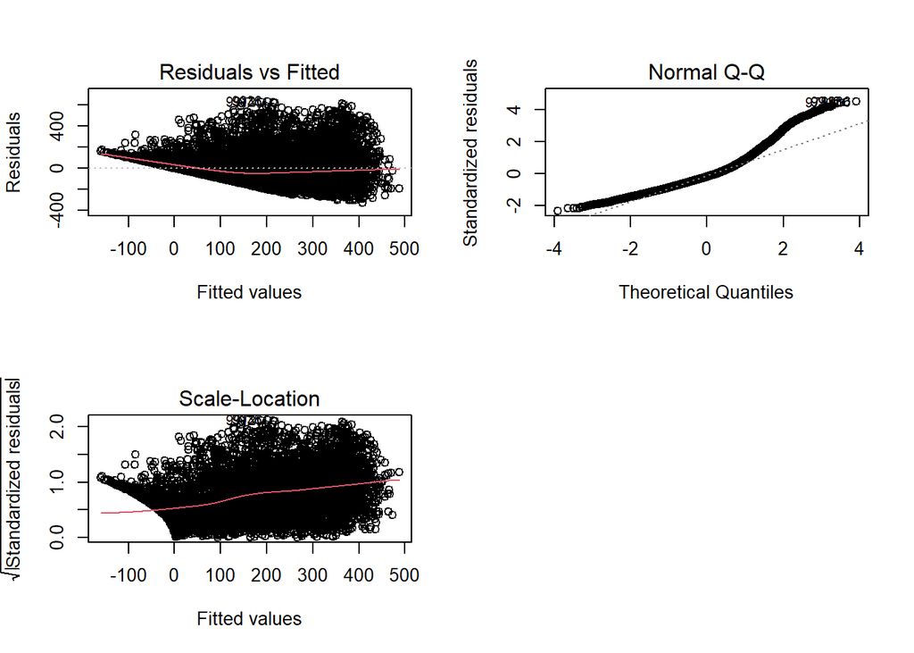

```r
par(mfrow = c(2,2))
plot(lm_model, which = c(1,2,3))
```

In the residuals vs fitted plot, the variance of residuals increased as the values increased. So we tested a log transformation.

```r
lm_model2 <- lm(log(count) ~ ., data = training_df)
summary(lm_model2)
```

```
##
## Call:
## lm(formula = log(count) ~ ., data = training_df)
##
## Residuals:
##     Min      1Q  Median      3Q     Max
## -4.0840 -0.6233  0.1166  0.6861  3.1649
##
## Coefficients:
##               Estimate Std. Error t value Pr(>|t|)
## (Intercept) -8.583e+02  4.139e+01 -20.737  < 2e-16 ***
## season2     -1.118e-02  5.198e-02  -0.215  0.82968
## season3     -3.449e-01  8.735e-02  -3.949 7.90e-05 ***
## season4     -3.988e-02  1.168e-01  -0.341  0.73292
## holiday     -4.406e-02  6.396e-02  -0.689  0.49088
## workingday  -9.960e-02  2.263e-02  -4.402 1.09e-05 ***
## weather2     1.465e-01  2.484e-02   5.897 3.81e-09 ***
## weather3    -2.447e-01  4.197e-02  -5.831 5.67e-09 ***
## weather4     1.111e+00  1.063e+00   1.046  0.29581
## temp         3.452e-02  8.334e-03   4.142 3.47e-05 ***
## atemp        2.265e-02  7.308e-03   3.100  0.00194 **
## humidity    -1.383e-02  6.693e-04 -20.664  < 2e-16 ***
## windspeed    4.525e-03  1.376e-03   3.289  0.00101 **
## year         4.280e-01  2.058e-02  20.800  < 2e-16 ***
## day          2.728e-03  1.862e-03   1.465  0.14290
## month        6.915e-02  1.265e-02   5.468 4.64e-08 ***
## hour         1.024e-01  1.578e-03  64.901  < 2e-16 ***
## dayofweek    2.306e-02  5.127e-03   4.498 6.92e-06 ***
## ---
## Signif. codes:  0 '***' 0.001 '**' 0.01 '*' 0.05 '.' 0.1 ' ' 1
##
## Residual standard error: 1.062 on 10868 degrees of freedom
## Multiple R-squared:  0.4919, Adjusted R-squared:  0.4911
## F-statistic: 618.9 on 17 and 10868 DF,  p-value: < 2.2e-16
```

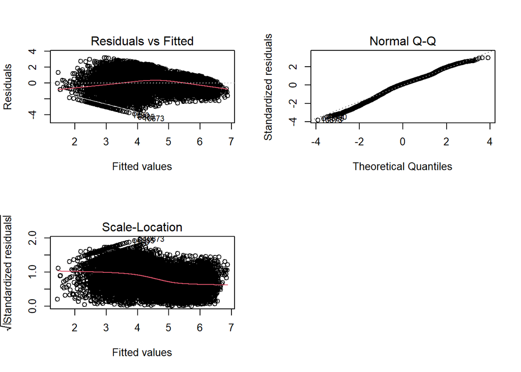

```r
par(mfrow = c(2,2))
plot(lm_model2, which = c(1,2,3))
```

## Model Selection

```r
lm_model3 <- lm(log(count) ~ .-holiday -day, data = training_df) # no holiday and day
anova(lm_model3,lm_model2)
```

```
## Analysis of Variance Table
##
## Model 1: log(count) ~ (season + holiday + workingday + weather + temp +
##     atemp + humidity + windspeed + year + day + month + hour +
##     dayofweek) - holiday - day
## Model 2: log(count) ~ season + holiday + workingday + weather + temp +
##     atemp + humidity + windspeed + year + day + month + hour +
##     dayofweek
##   Res.Df   RSS Df Sum of Sq      F Pr(>F)
## 1  10870 12266
## 2  10868 12263  2    2.9945 1.3269 0.2653
```

There’s no evidence that including holiday and day improves the model’s fit.

```r
summary(lm_model3)
```

```
##
## Call:
## lm(formula = log(count) ~ . - holiday - day, data = training_df)
##
## Residuals:
##     Min      1Q  Median      3Q     Max
## -4.0825 -0.6250  0.1178  0.6854  3.1564
##
## Coefficients:
##               Estimate Std. Error t value Pr(>|t|)
## (Intercept) -8.580e+02  4.139e+01 -20.730  < 2e-16 ***
## season2     -1.410e-02  5.186e-02  -0.272 0.785798
## season3     -3.516e-01  8.696e-02  -4.044 5.30e-05 ***
## season4     -4.886e-02  1.161e-01  -0.421 0.673989
## workingday  -9.544e-02  2.192e-02  -4.354 1.35e-05 ***
## weather2     1.466e-01  2.484e-02   5.900 3.74e-09 ***
## weather3    -2.456e-01  4.196e-02  -5.853 4.96e-09 ***
## weather4     1.111e+00  1.063e+00   1.045 0.296008
## temp         3.451e-02  8.325e-03   4.145 3.42e-05 ***
## atemp        2.271e-02  7.301e-03   3.110 0.001875 **
## humidity    -1.383e-02  6.693e-04 -20.659  < 2e-16 ***
## windspeed    4.587e-03  1.375e-03   3.336 0.000852 ***
## year         4.278e-01  2.058e-02  20.793  < 2e-16 ***
## month        7.011e-02  1.257e-02   5.577 2.50e-08 ***
## hour         1.024e-01  1.578e-03  64.892  < 2e-16 ***
## dayofweek    2.340e-02  5.103e-03   4.586 4.58e-06 ***
## ---
## Signif. codes:  0 '***' 0.001 '**' 0.01 '*' 0.05 '.' 0.1 ' ' 1
##
## Residual standard error: 1.062 on 10870 degrees of freedom
## Multiple R-squared:  0.4918, Adjusted R-squared:  0.4911
## F-statistic: 701.2 on 15 and 10870 DF,  p-value: < 2.2e-16
```

```r
anova(lm_model3)
```

```
## Analysis of Variance Table
##
## Response: log(count)
##               Df  Sum Sq Mean Sq  F value    Pr(>F)
## season         3  1216.0   405.3  359.189 < 2.2e-16 ***
## workingday     1     7.8     7.8    6.916 0.0085546 **
## weather        3   314.1   104.7   92.790 < 2.2e-16 ***
## temp           1  3155.7  3155.7 2796.544 < 2.2e-16 ***
## atemp          1    12.5    12.5   11.084 0.0008735 ***
## humidity       1  1952.6  1952.6 1730.369 < 2.2e-16 ***
## windspeed      1    33.6    33.6   29.776 4.956e-08 ***
## year           1   358.7   358.7  317.849 < 2.2e-16 ***
## month          1    50.6    50.6   44.882 2.196e-11 ***
## hour           1  4743.5  4743.5 4203.623 < 2.2e-16 ***
## dayofweek      1    23.7    23.7   21.027 4.579e-06 ***
## Residuals  10870 12266.0     1.1
## ---
## Signif. codes:  0 '***' 0.001 '**' 0.01 '*' 0.05 '.' 0.1 ' ' 1
```

This means that removing any more variables would reduce model fit .

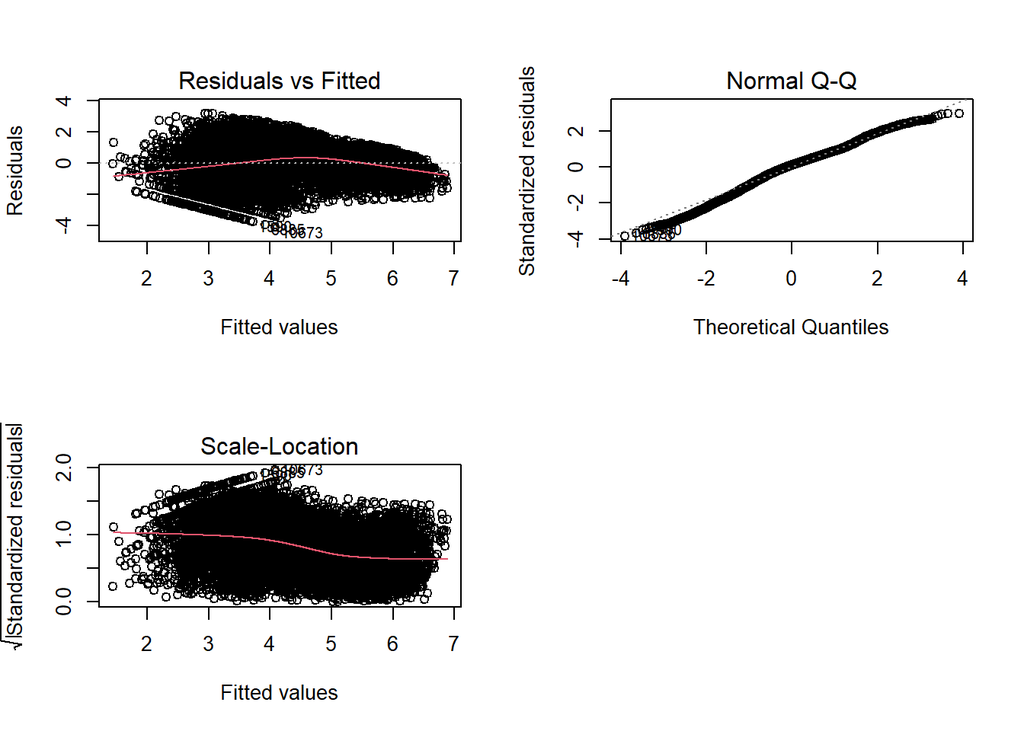

```r
par(mfrow = c(2,2))
plot(lm_model3, which = c(1,2,3))
```

Which variables are useful for predicting the number of bikes used in an hour? All variables other than holiday and day.

How does temperature affect the number of bikes in use? The graphs show bikers increase with higher temperatures. In the model, we also see a slight increase in the number of bikers when temperature increases.

## Logit Model

SMART Question 4: Can we estimate when it is a holiday depending on other bikeshare factors?

```r
logclean = training_df
logclean$y = logclean[,2] # renaming holiday to y
logclean = logclean[,-2] # removing holiday
logclean = logclean[,-5] # removing atemp
logclean = logclean[,-8] # removing year
logclean = logclean[,-9] # removing month
logclean = logclean[,-9] # removing hour
logclean = logclean[,-9] # removing dayofweek

#convert columns into factors
logclean$workingday = factor(logclean$workingday)
logclean$y <- ifelse(logclean$y == 1,TRUE,FALSE)
logclean$y = factor(logclean$y)

str(logclean)
```

```
## 'data.frame':    10886 obs. of  9 variables:
##  $ season    : Factor w/ 4 levels "1","2","3","4": 1 1 1 1 1 1 1 1 1 1 ...
##  $ workingday: Factor w/ 2 levels "0","1": 1 1 1 1 1 1 1 1 1 1 ...
##  $ weather   : Factor w/ 4 levels "1","2","3","4": 1 1 1 1 1 2 1 1 1 1 ...
##  $ temp      : num  9.84 9.02 9.02 9.84 9.84 ...
##  $ humidity  : int  81 80 80 75 75 75 80 86 75 76 ...
##  $ windspeed : num  0 0 0 0 0 ...
##  $ count     : int  16 40 32 13 1 1 2 3 8 14 ...
##  $ day       : int  1 1 1 1 1 1 1 1 1 1 ...
##  $ y         : Factor w/ 2 levels "FALSE","TRUE": 1 1 1 1 1 1 1 1 1 1 ...
```

```r
log.bestglm <- bestglm(Xy = logclean, family = binomial,
            IC = "AIC",
            method = "exhaustive")
```

```
## Morgan-Tatar search since family is non-gaussian.
```

```
## Note: factors present with more than 2 levels.
```

```r
summary(log.bestglm)
```

```
## Fitting algorithm:  AIC-glm
## Best Model:
##               df deviance
## Null Model 10880 2072.355
## Full Model 10885 2824.513
##
##  likelihood-ratio test - GLM
##
## data:  H0: Null Model vs. H1: Best Fit AIC-glm
## X = 752.16, df = 5, p-value < 2.2e-16
```

```r
log.bestglm$BestModels
```

```
##   season workingday weather  temp humidity windspeed count   day Criterion
## 1   TRUE       TRUE   FALSE FALSE    FALSE      TRUE FALSE FALSE  2082.355
## 2   TRUE       TRUE   FALSE FALSE    FALSE     FALSE FALSE FALSE  2082.491
## 3   TRUE       TRUE   FALSE FALSE    FALSE      TRUE FALSE  TRUE  2082.647
## 4   TRUE       TRUE   FALSE FALSE    FALSE     FALSE FALSE  TRUE  2083.100
## 5   TRUE       TRUE    TRUE FALSE    FALSE      TRUE FALSE FALSE  2083.586
```

```r
summary(log.bestglm$BestModels)
```

```
##   season        workingday      weather           temp          humidity
##  Mode:logical   Mode:logical   Mode :logical   Mode :logical   Mode :logical
##  TRUE:5         TRUE:5         FALSE:4         FALSE:5         FALSE:5
##                                TRUE :1
##
##
##
##  windspeed         count            day            Criterion
##  Mode :logical   Mode :logical   Mode :logical   Min.   :2082
##  FALSE:2         FALSE:5         FALSE:3         1st Qu.:2082
##  TRUE :3                         TRUE :2         Median :2083
##                                                  Mean   :2083
##                                                  3rd Qu.:2083
##                                                  Max.   :2084
```

The best model has AIC of 2082, with only variables `season`, `windspeed` and `workingday`. Although this AIC is quite high, this is the model that has the best fit for predicting if it’s a holiday.

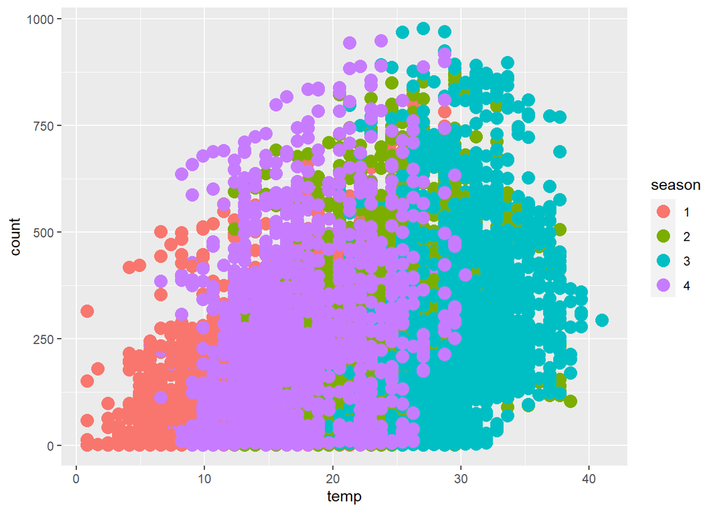

```r
library(ggplot2)
library(ISLR)
p1 <- ggplot(training_df,aes(temp, count, color = season))
print(p1 + geom_point(size = 4))
```

## decision tree

```r
table(training_df$workingday)
```

```
##
##    0    1
## 3474 7412
```

```r
copied_df = data.frame(training_df)



library(rpart)
library(rpart.plot)
library(randomForest)
copied_df = copied_df[, -c(1,4)]

train_percentage <- 0.8

# Generate random indices for the training set
indices <- sample(1:nrow(copied_df), size = round(train_percentage * nrow(copied_df)), replace = FALSE)

# Create the training set
train_set <- copied_df[indices, ]

# Create the testing set
test_set <- copied_df[-indices, ]


train_features <- train_set[, -which(names(train_set) == "temp")]
train_target <- train_set$temp

# Separate features and target in the testing set
test_features <- test_set[, -which(names(test_set) == "temp")]
test_target <- test_set$temp


tree <- rpart(train_target ~ .,method = 'anova', data = train_features,minsplit = 5)

predictions <- predict(tree, newdata = test_features)

rmse <- sqrt(mean((test_target - predictions)^2))

# Display the RMSE
print(paste("Root Mean Squared Error:", rmse))
```

```
## [1] "Root Mean Squared Error: 1.63930955702847"
```

```r
printcp(tree)
```

```
##
## Regression tree:
## rpart(formula = train_target ~ ., data = train_features, method = "anova",
##     minsplit = 5)
##
## Variables actually used in tree construction:
## [1] atemp
##
## Root node error: 526630/8709 = 60.47
##
## n= 8709
##
##         CP nsplit rel error   xerror      xstd
## 1 0.722387      0  1.000000 1.000277 0.0111872
## 2 0.098687      1  0.277613 0.277708 0.0041558
## 3 0.078523      2  0.178927 0.178990 0.0034516
## 4 0.017849      3  0.100404 0.100478 0.0034519
## 5 0.017422      4  0.082555 0.078145 0.0032942
## 6 0.012938      5  0.065133 0.065210 0.0028893
## 7 0.011502      6  0.052195 0.052274 0.0027890
## 8 0.010000      7  0.040693 0.040860 0.0027733
```

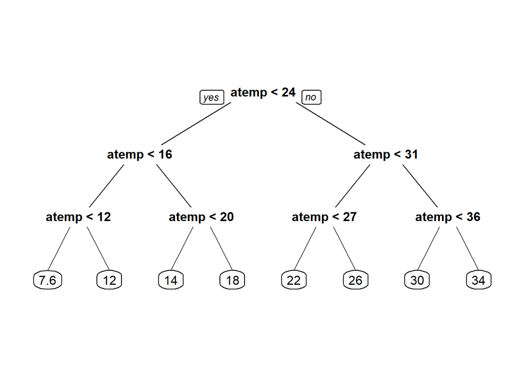

```r
prp(tree)
```

```r
rf.model <- randomForest(train_target ~ ., method = 'anova', data = train_features)


predictions_rfm <- predict(rf.model, newdata = test_features)

rmse_rfm <- sqrt(mean((test_target - predictions_rfm)^2))

print(rf.model)
```

```
##
## Call:
##  randomForest(formula = train_target ~ ., data = train_features,      method = "anova")
##                Type of random forest: regression
##                      Number of trees: 500
## No. of variables tried at each split: 3
##
##           Mean of squared residuals: 0.2662038
##                     % Var explained: 99.56
```

```r
print(paste("Root Mean Squared Error for rfm:", rmse_rfm))
```

```
## [1] "Root Mean Squared Error for rfm: 0.527841995764899"
```

```r
print(rmse_rfm)
```

```
## [1] 0.527842
```

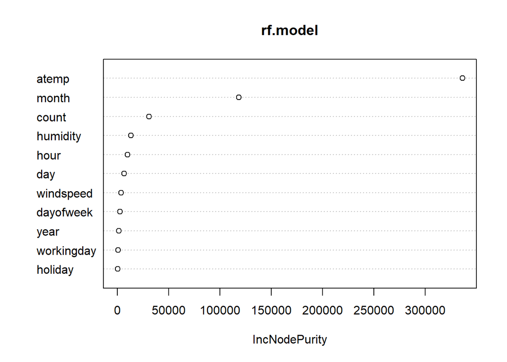

```r
varImpPlot(rf.model)
```